# Gibbs sampler with `R`

Dhafer Malouche

9/7/2018

## Gibbs sampler

**What’s a Gibbs Sampler**

- It’s an algorithm for simulating Markov chains.
- Let $\theta=(\theta_1,\ldots,\theta_k)$ be a random vector with joint distribution $f$,
- *Aim*: simulate a sample with distribution $f$.

**How it works?**

1. Choose arbitrary starting values: $\theta^{(0)}=(\theta_1^{(0)},\ldots,\theta_k^{(0)})$
2. Sample new values for each element of $\theta$ by cycling through the following steps:
- Sample a new value for $\theta_1^{(1)}$ from the full *conditional distribution* of $\theta_1$ given the most recent values of all other elements of $\theta$:
  $$\theta_1^{(1)}\sim p\left(\theta_1 \mid\theta_2^{(0)},\ldots,\theta_k^{(0)} \right)$$
- Sample a new value $\theta_2^{(1)}$ for the 2nd component of $\theta$, from its full *conditional distribution*
  $$\theta_2^{(1)}\sim p\left(\theta_2 \mid\theta_1^{(1)},\theta_3^{(0)}\ldots,\theta_k^{(0)} \right)$$
- …
- $\theta_k^{(1)}\sim p\left(\theta_1 \mid\theta_1^{(1)},\theta_2^{(1)}\ldots,\theta_{k-1}^{(1)} \right)$

This completes one iteration of the Gibbs sampler and generates a new realization of the vector of unknowns $\theta^{(1)}$.

3. Repeat Step 2 many times and obtain a sample $\theta^{(1)},\ldots, \theta^{(T)}$

To better understand the Gibbs Sampler, I suggest to read the paper by Casela and George 1992

## Markov Chain

- $\theta^{(1)},\ldots, \theta^{(T)}$ is a Markov Chain
- If $\theta^{(1)},\ldots, \theta^{(T)}$ converges, then from $N$, $\theta^{(N)},\ldots, \theta^{(N)}$ is a sample with $f$ distribution
- `coda` and `codadiags` two `R` packages for convergence diagnostics

## Example 1: Posterior of the couple mean and precision of a Normal distribution

**Problem**

Suppose that we had observed a sample $y_1,\ldots,n$ generated from random variable $Y\sim\mathcal{N}\left(\mbox{mean}=\mu,\,\mbox{Var}=1/\tau\right)$ where $\mu$ and $\tau$ are unknown. Suppose also that we had defined the following prior distribution
$$f(\mu,\,\tau) \propto 1/\tau$$

Based on a sample, obtain the posterior distributions of $\mu$ and $\tau$ using the Gibbs sampler and write an `R` code simulating this posterior distribution.

**Solution**

We can first prouve that

- Conditional posterior for the mean, given the precision is given by

$$\mu\mid y_1,\ldots,y_n,\tau \sim \mathcal{N}\left(\overline{y},\displaystyle\frac{1}{n\tau}\right)$$

- Conditional posterior for the precision, given the mean

$$\tau\mid y_1,\ldots,y_n,\mu \sim \mbox{Gamma}\left(\displaystyle\frac{n}{2},\displaystyle\frac{2}{(n-1)s^2+n(\mu-\overline{y})^2}\right)$$
where
$$\overline{y}=\displaystyle\frac{1}{n}\sum_{i=1}^n y_i$$
is the sample mean and
$$s^2=\displaystyle\frac{1}{n-1}\sum_{i=1}^n (y_i-\overline{y})^2$$
is the sample variance.

Let’s then implement then the Gibbs Sampler into `R`. Here’s the code

```r
> # The data
> n    <- 40
> ybar <- 35
> s2   <- 5
>
> # sample from the joint posterior (mu, tau | data)
> mu     <- rep(NA, 11000)
> tau    <- rep(NA, 11000)
> T      <- 1000    # burnin
> tau[1] <- 1  # initialisation
> for(i in 2:11000) {
+     mu[i]  <- rnorm(n = 1, mean = ybar, sd = sqrt(1 / (n * tau[i - 1])))
+     tau[i] <- rgamma(n = 1, shape = n / 2, scale = 2 / ((n - 1) * s2 + n * (mu[i] - ybar)^2))
+ }
> mu  <- mu[-(1:T)]   # remove burnin
> tau <- tau[-(1:T)] # remove burnin
```

Let’s quickly visualize the marginal distribution obtained from the sample runned above.

```r
> summary(mu)
```

```
   Min. 1st Qu.  Median    Mean 3rd Qu.    Max.
  33.25   34.75   35.00   35.00   35.24   36.50
```

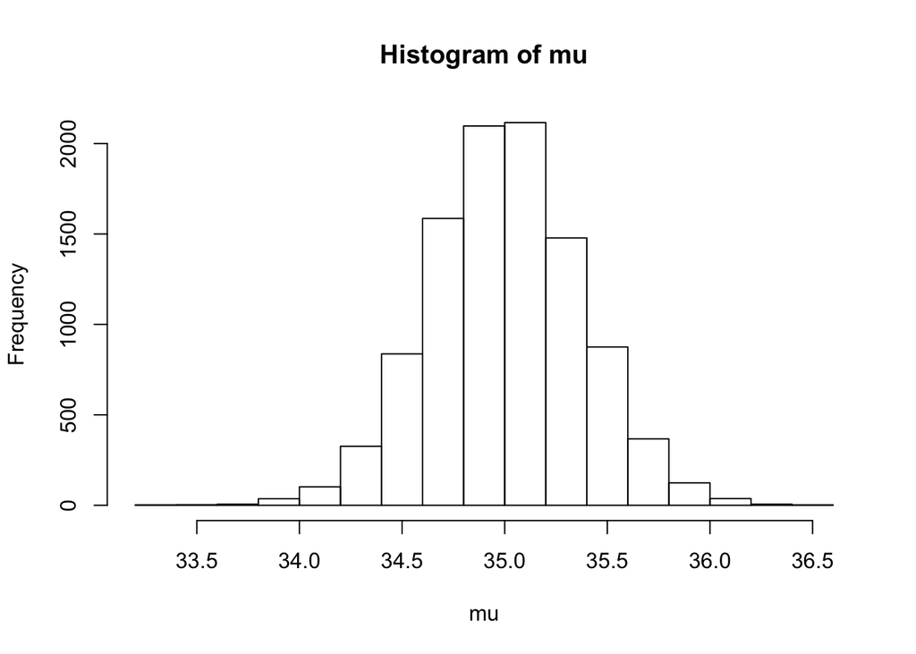

```r
> hist(mu)
```

```r
> summary(1/tau)
```

```
   Min. 1st Qu.  Median    Mean 3rd Qu.    Max.
  2.328   4.390   5.101   5.281   5.965  14.821
```

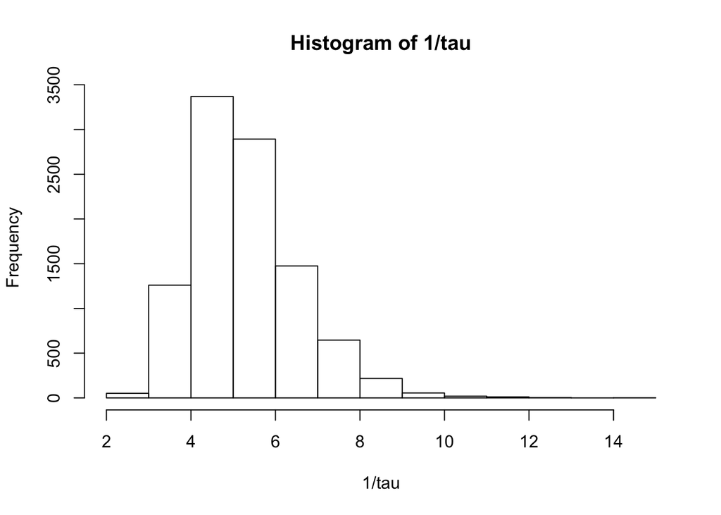

```r
> hist(1/tau)
```

## Example 2: Bivariate Gaussian Distribution

Let
$$\theta=(\theta_1,\,\theta_2)\sim \mathcal{N}_2(0,I_2)$$
with density function
$$f(\theta_1,\,\theta_2)=\displaystyle\frac{1}{\sqrt{2\pi}}\exp\left(-\displaystyle\frac{1}{2}(\theta_1^2+\theta_2^2)\right)$$

1. Compute the distributions of $\theta_1 \mid \theta_2$ and $\theta_2 \mid \theta_1$
2. Write an `R` code based on the Gibbs algorithm to simulate a sample with a Standard bivariate Gaussian distribution.